# Rapport **R**

guangnan WEI

27/10/2020

**Quels types de raisins ont un impact sur la relation entre la qualité du vin et le prix?**

## 1. Introduction

> –>On juge la qualité du vin en fonction de la note.Habituellement, on pensera que le vin avec une note de 85 ou plus est un vin de bonne qualité . On sait que de nombreux facteurs affectent la qualité du vin, tels que le type de raisin, les conditions climatiques , la qualité de la cave à vin, etc. Cependant la note peut également être lié aux idées subjectives des dégustateurs. Dans l’analyse suivante, on suppose que l’influence de dégusteurs est nulle ,et plus la note est élevé, meilleure est la qualité du vin.  
> **Problématique:** Le vin de meilleure qualité est-il donc plus cher?  
> Les types de raisin qui affectent la relation entre la qualité du vin et le prix sont-ils les mêmes dans les différentes provinces?

> –>[Source de data](https://github.com/Da11tura/tidytuesday/tree/master/data/2019/2019-05-28)

### 1.1 Explication des variables

| variable | description |
| --- | --- |
| country | Pays d’origine |
| description | Saveurs et profil de goût rédigé par le critique |
| designation | Le vignoble dans la cave d’où proviennent les raisins qui ont fait le vin |
| points | La notation que WineEnthusiast a noté le vin sur une échelle de 1 à 100 **(bien qu’ils disent qu’ils ne publient que des critiques pour les vins qui obtiennent> = 80)** |
| price | Le coût d’une bouteille de vin |
| province | La province ou l’État d’origine du vin |
| region_1 | La zone viticole d’une province ou d’un état (c.-à-d. Napa) |
| taster_name | Le dégustateur / critique |
| title | Le titre de la revue de vin, qui contient souvent le millésime (année) |
| variety | Type de raisin |
| winery | La cave qui a fait le vin |

### 1.2 Importation de données

```
## # A tibble: 129,971 x 14
##       X1 country description designation points price province region_1 region_2
##    <dbl> <chr>   <chr>       <chr>        <dbl> <dbl> <chr>    <chr>    <chr>
##  1     0 Italy   Aromas inc… Vulkà Bian…     87    NA Sicily … Etna     <NA>
##  2     1 Portug… This is ri… Avidagos        87    15 Douro    <NA>     <NA>
##  3     2 US      Tart and s… <NA>            87    14 Oregon   Willame… Willame…
##  4     3 US      Pineapple … Reserve La…     87    13 Michigan Lake Mi… <NA>
##  5     4 US      Much like … Vintner's …     87    65 Oregon   Willame… Willame…
##  6     5 Spain   Blackberry… Ars In Vit…     87    15 Norther… Navarra  <NA>
##  7     6 Italy   Here's a b… Belsito         87    16 Sicily … Vittoria <NA>
##  8     7 France  This dry a… <NA>            87    24 Alsace   Alsace   <NA>
##  9     8 Germany Savory dri… Shine           87    12 Rheinhe… <NA>     <NA>
## 10     9 France  This has g… Les Natures     87    27 Alsace   Alsace   <NA>
## # … with 129,961 more rows, and 5 more variables: taster_name <chr>,
## #   taster_twitter_handle <chr>, title <chr>, variety <chr>, winery <chr>
```

## 2. Analyse des données

### 2.1 Extraction de données

> –>Afin de rendre la table de données plus lisible, élimine ces variables inutiles

```r
wine_use<- wine_ratings%>%
  select(-X1,-description,-taster_name,-region_2,-taster_twitter_handle,-title,-winery,-designation)
wine_use
```

```
## # A tibble: 129,971 x 6
##    country  points price province          region_1            variety
##    <chr>     <dbl> <dbl> <chr>             <chr>               <chr>
##  1 Italy        87    NA Sicily & Sardinia Etna                White Blend
##  2 Portugal     87    15 Douro             <NA>                Portuguese Red
##  3 US           87    14 Oregon            Willamette Valley   Pinot Gris
##  4 US           87    13 Michigan          Lake Michigan Shore Riesling
##  5 US           87    65 Oregon            Willamette Valley   Pinot Noir
##  6 Spain        87    15 Northern Spain    Navarra             Tempranillo-Merl…
##  7 Italy        87    16 Sicily & Sardinia Vittoria            Frappato
##  8 France       87    24 Alsace            Alsace              Gewürztraminer
##  9 Germany      87    12 Rheinhessen       <NA>                Gewürztraminer
## 10 France       87    27 Alsace            Alsace              Pinot Gris
## # … with 129,961 more rows
```

### 2.2 Analyse statistique des données

```r
#install.packages("skimr")
library(skimr)
skim(wine_use)
```

Data summary

| Name | wine_use |
| --- | --- |
| Number of rows | 129971 |
| Number of columns | 6 |
| _______________________ |  |
| Column type frequency: |  |
| character | 4 |
| numeric | 2 |
| ________________________ |  |
| Group variables | None |

**Variable type: character**

| skim_variable | n_missing | complete_rate | min | max | empty | n_unique | whitespace |
| --- | --- | --- | --- | --- | --- | --- | --- |
| country | 63 | 1.00 | 2 | 22 | 0 | 43 | 0 |
| province | 63 | 1.00 | 3 | 31 | 0 | 425 | 0 |
| region_1 | 21247 | 0.84 | 3 | 50 | 0 | 1229 | 0 |
| variety | 1 | 1.00 | 4 | 35 | 0 | 707 | 0 |

**Variable type: numeric**

[output not shown]

### 2.2.1 Analyse du nombre d’échantillons avec la note supérieur à 88.4 dans les échantillons de vin de chaque pays

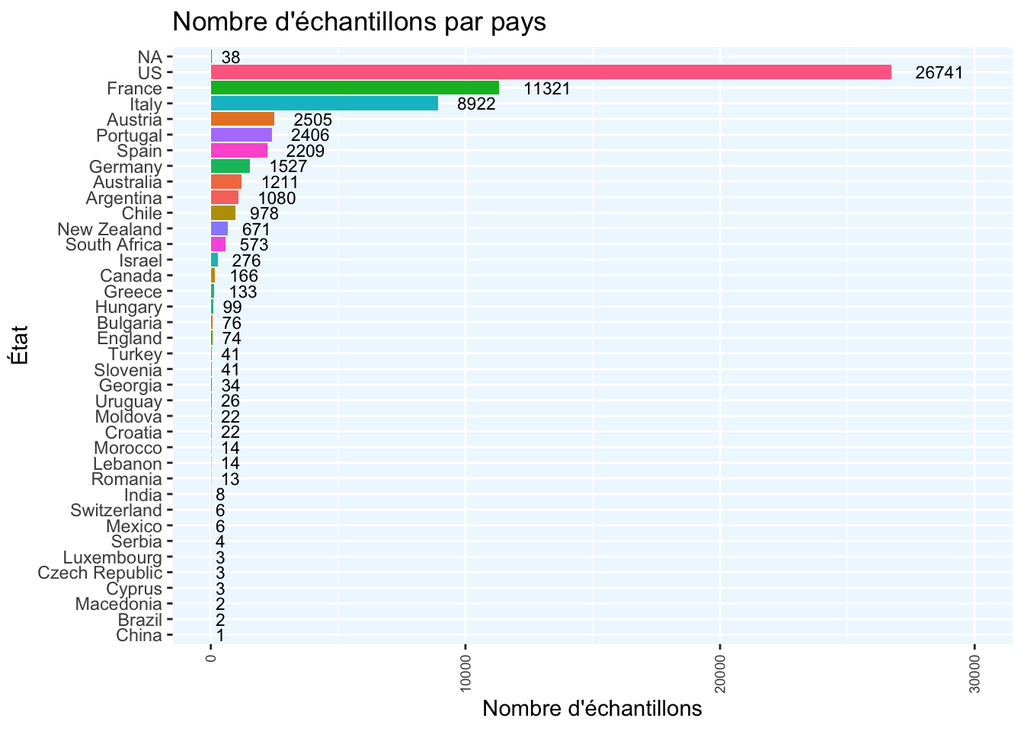

```r
wine_use%>%
  filter(points>=88.4)%>%
  group_by(country)%>%
  summarise(n=n())%>%
  ggplot(aes(x=reorder(country,n),y=n))+
  geom_text(aes(label=paste0(n)),hjust=-0.5,size=3)+
  geom_col(aes(fill=country))+
  theme(axis.text.x = element_text(size = 7,angle = 90, vjust = 0.5,                    hjust=1),legend.position="none",panel.background=element_rect(fill="aliceblue"))+
  labs(title="Nombre d'échantillons par pays",y="Nombre d'échantillons",x="État")+
  ylim(0,30000)+
  coord_flip()
```

> –>Pour les échatillons qui ont le note supérieur à 88.4,les États-Unis ont le plus grand nombre d’échantillons, suivis de la France et de l’Italie .On peut penser que la qualité moyenne des vins de ces trois pays est très élevée. Ensuite, on analyse la proportion de vins de meilleure qualité dans tous les vins de ces pays qui ont le nombre d’échantillons avec la note supérieur à 88,4 dépasse 1000).

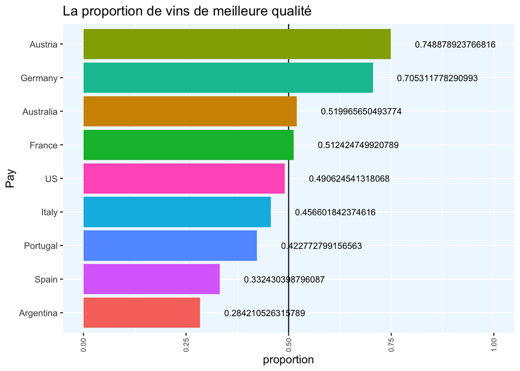

> –>On constate que l’Autriche, l’Australie, l’Allemagne et la France ont un ratio de plus de 0,5 dans ces pays, ce qui signifie que plus de la moitié des échantillons de ces pays ont des notes supérieurs à la moyenne 88.4 , Donc pour la suite ,on va seulement analyser les échantillons sur la France.

### 2.3 Quelle province de France a la qualité la plus élevée pour les vins qui sont “Red Blend” et le prix est inférieur à 33,5?

```r
wine_use%>%
  filter( price<33.5 & variety==c("Red Blend","Bordeaux-style Red Blend") & country=="France")->wine_use1
```

> –>Grâce à la boîte à moustaches, on ne peut pas observer plus intuitivement, parce que la qualité de la Loire Valley et la qualité de la Provence sont très proche

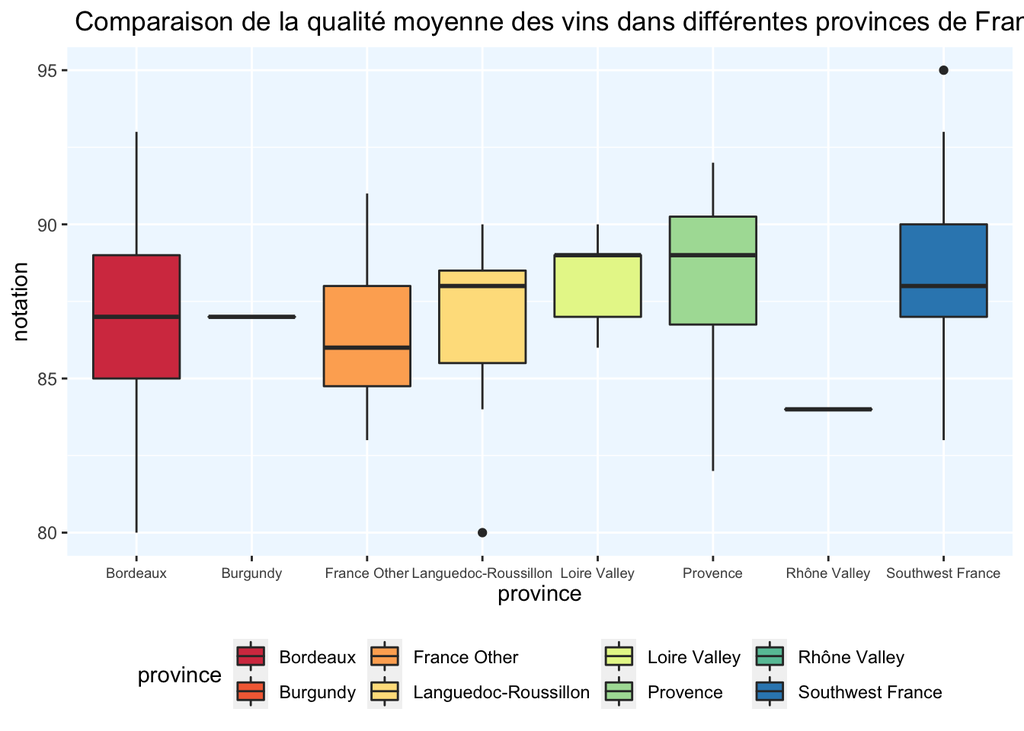

```r
wine_use1%>%
  group_by(province)%>%
  ggplot(aes(x=province,y=points,,fill=province))+
  geom_boxplot()+
  ggtitle(" Comparaison de la qualité moyenne des vins dans différentes provinces de France ")+
  labs(y="notation")+
  theme(axis.text.x = element_text(size = 7, vjust = 0.5, hjust = 0.5),legend.position="bottom")+
  scale_fill_brewer(palette = "Spectral")+
  theme(panel.background =element_rect(fill="aliceblue"))
```

> –>Parmi tous les “Red Blend” dont le prix est inférieur à 33,5, la qualité moyenne des vins de Loire Valley est supérieur à celui des autres régions.

```r
wine_use1%>%
  group_by(province)%>%
  summarise(mean_points_province=mean(points))%>%
  arrange(-mean_points_province)
```

```
## # A tibble: 8 x 2
##   province             mean_points_province
##   <chr>                               <dbl>
## 1 Loire Valley                         88.2
## 2 Provence                             88.2
## 3 Southwest France                     88.1
## 4 Bordeaux                             87.1
## 5 Burgundy                             87
## 6 Languedoc-Roussillon                 86.7
## 7 France Other                         86.4
## 8 Rhône Valley                         84
```

### 2.4 En France,la relation entre la qualité et le prix

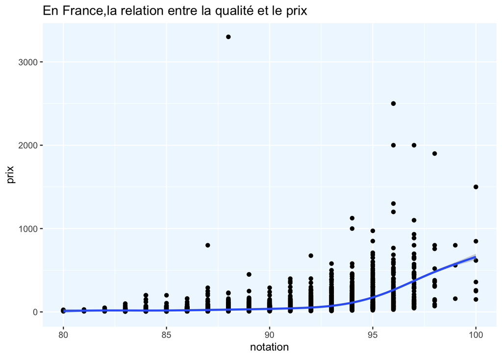

```r
wine_use%>%
  filter(country=="France")%>%
  ggplot(aes(x=points,y=price))+
  geom_point()+
  geom_smooth()+
  theme(panel.background =element_rect(fill="aliceblue"))+
  labs(title="En France,la relation entre la qualité et le prix",y="prix",x="notation")
```

> –> En général, Le prix du vin augmente à mesure que la quantité augmente.

### 2.4.1 Analyser la relation entre la qualité et le prix dans les différentes provinces ?

> –>Selon le graphique ci-dessus, La plupart des points distribuent entre 0 et 1000. Par conséquent, on doit modifier la limite d’affichage de l’axe y entre 0 et 1000.

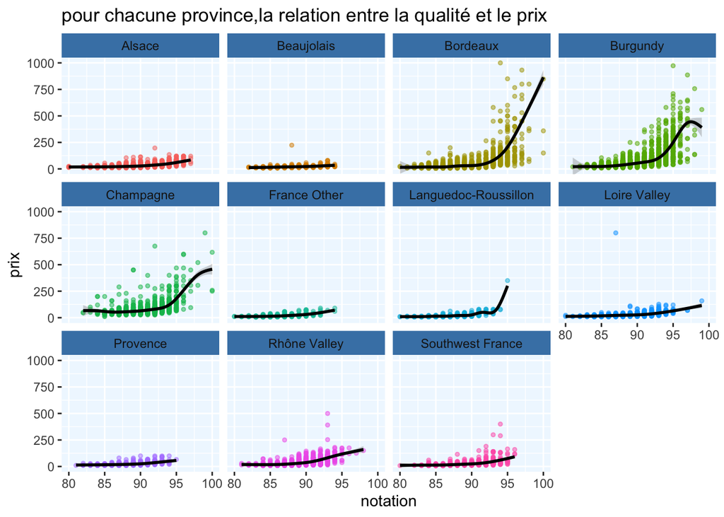

```r
wine_use%>%
  filter(country=="France")%>%
  ggplot(aes(x=points,y=price,col=province))+
  geom_point(size=1,alpha = 0.5)+
  geom_smooth(col="black")+
  facet_wrap(~ province)+
  coord_cartesian(ylim = c(0,1000))+
  theme(legend.position = "none" ,
        panel.background =element_rect(fill="aliceblue"),
        strip.background = element_rect(fill="#4682B4"),
        )+
  labs(title="pour chacune province,la relation entre la qualité et le prix",y="prix",x="notation")
```

> –>Donc on peux estimer que le prix des vins qui viennent des provinces Bordeaux, Burgundy et Champagne , est plus touché par la qualité des vins .

### 2.4.2 Quels types de raisin sont principalement produits dans ces trois provinces viticoles?

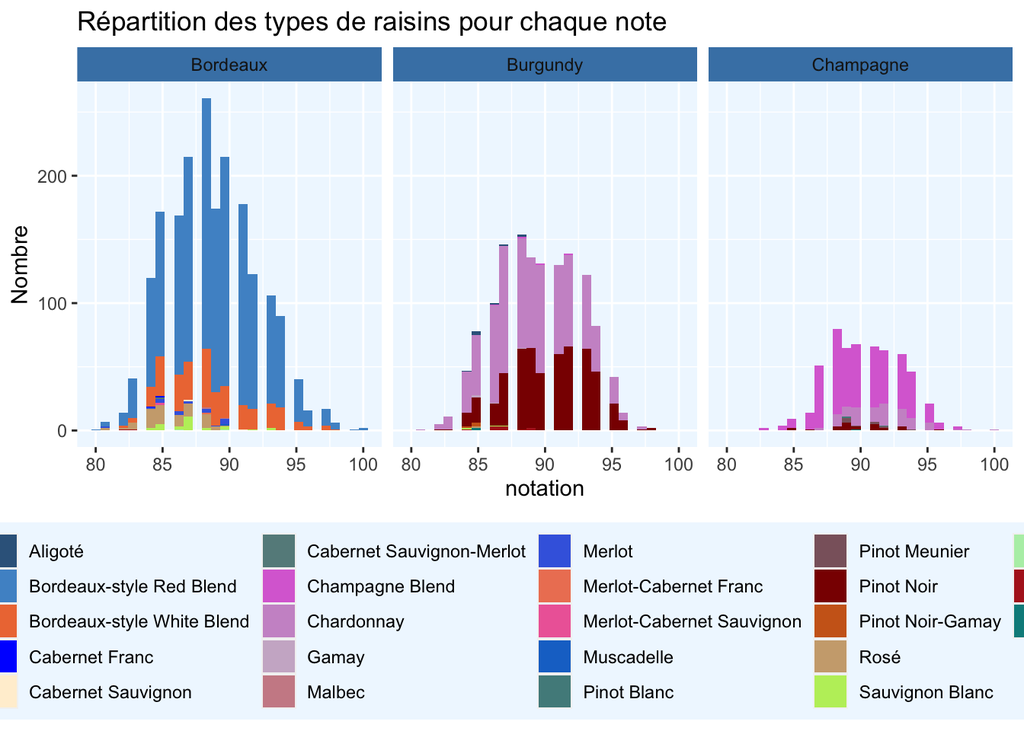

```r
wine_use%>%
  filter(country=="France",province==c("Bordeaux","Burgundy","Champagne"))-> wine_use2

wine_use2%>%
  group_by(province,variety)%>%
  ggplot(aes(x=points,fill=variety))+
  geom_histogram()+
  scale_fill_manual(values=c("steelblue4","steelblue3","sienna2","blue","papayawhip","paleturquoise4","orchid","plum3","thistle3","lightpink3","royalblue","salmon2","hotpink2","dodgerblue3","darkslategray4","pink4","darkred","chocolate3","burlywood3","darkolivegreen2","darkseagreen2","firebrick","darkcyan"))+
  facet_wrap(~ province)+
  theme(legend.position="bottom",
        panel.background =element_rect(fill="aliceblue"),
        strip.background = element_rect(fill="#4682B4"),
        legend.background = element_rect(fill="aliceblue"))+
  labs(title="Répartition des types de raisins pour chaque note",y="Nombre",x="notation")
```

> –> Bordeaux produit principalement le vin vient de raisin “Bordeaux-style Red Blend” , “Bordeaux-style White Blend” et rosé. –> Burgundy produit principalement le vin vient de “Chardonnay” et “Pinot Noir”. –> Champagne produit principalement le vin vient de “Champagne Blend” et “Chardonnay”.

### 2.4.3 Pour quelles variété de raisin , le prix de vin vient de celle est-il affecté par la qualité du vin à Bordeaux?

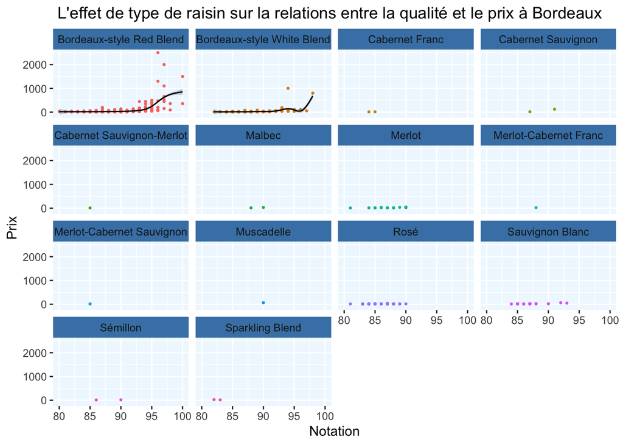

```r
wine_use2%>%
  filter(province=="Bordeaux")%>%
  ggplot(aes(x=points,y=price,col=variety))+
  geom_point(size=0.5)+
  facet_wrap(~ variety)+
  geom_smooth(col="black",size=0.5)+
    theme(legend.position = "none" ,
        panel.background =element_rect(fill="aliceblue"),
        strip.background = element_rect(fill="#4682B4"),
        )+
  labs(title=" L'effet de type de raisin sur la relations entre la qualité et le prix à Bordeaux" , y="Prix",x="Notation" )
```

> –>Selons ces graphiques , On peut penser que seul le prix du vin vient de raisin “Bordeaux-style Red Blend” est affecté par la qualité du vin , et plus la note est élevée, plus le prix est cher . Pour les autres types, sauf le vin vient de raisin “Bordeaux-style White Blend” , ils ne sont pas estimés, car il y a moins de observations .

### 2.4.4 Pour quelles variété de raisin , le prix de vin vient de celle est-il affecté par la qualité du vin à Burgundy?

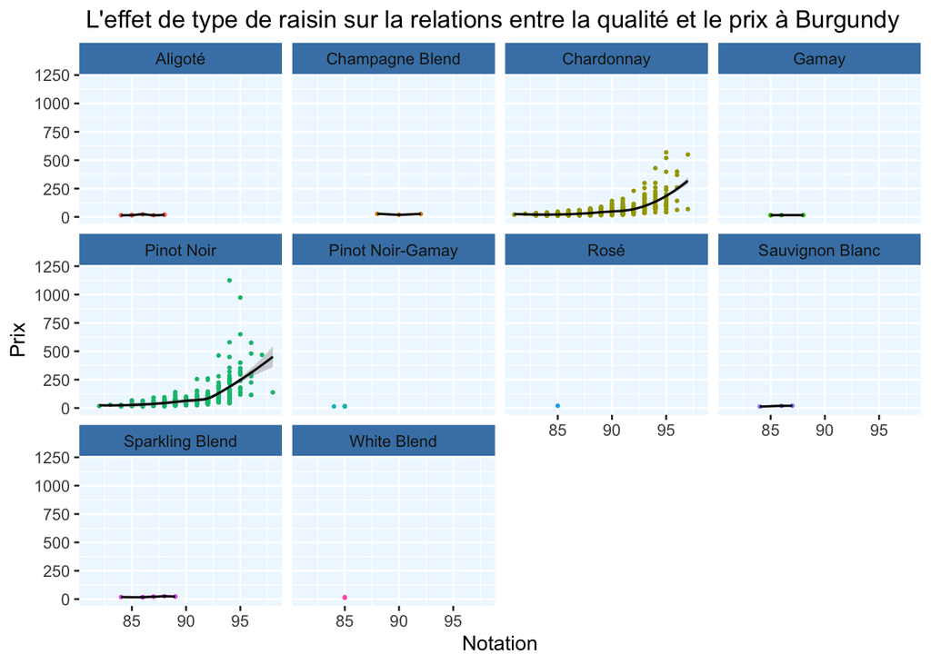

```r
wine_use2%>%
  filter(province=="Burgundy")%>%
  ggplot(aes(x=points,y=price,col=variety))+
  geom_point(size=0.5)+
  facet_wrap(~ variety)+
  geom_smooth(col="black",size=0.6)+
   theme(legend.position = "none" ,
        panel.background =element_rect(fill="aliceblue"),
        strip.background = element_rect(fill="#4682B4"),
        )+
  scale_y_continuous(limits = c(0,1200))+
  labs(title=" L'effet de type de raisin sur la relations entre la qualité et le prix à Burgundy" , y="Prix",x="Notation" )
```

> –>Selons ces graphiques , On peut penser que seul le prix de ces deux vins dont le vin vient de raisin “Chardonnay” et “Pinot Noir” est affecté par la qualité du vin , et plus le score est élevé, plus le prix est cher .Pour les autres types, , ils ne sont pas estimés, car il y a moins de observations .